# Sprawozdanie 7

Andrzej Miczek, Jakub Laszczyk

2023-12-05

## Wczytanie bibliotek

```r
library(VIM)
library(caret)
library(psych)
library(mlr)
library(DALEX)
library(rms)
library(ggplot2)
```

## Wczytanie danych

```r
dane <- read.csv("Heart2.csv", sep=";")
#dane[,c(1,3,4,6,8)] <- scale(dane[,c(1,3,4,6,8)])
dane$heartDisease <- as.factor(dane$heartDisease)
dane$FastingBS <- as.factor(dane$FastingBS)
dane$Sex <- as.factor(dane$Sex)
obserwacja <- dane[200,]
str(dane)
```

```
## 'data.frame':    818 obs. of  16 variables:
##  $ Age             : int  40 49 37 48 54 39 45 54 48 37 ...
##  $ Sex             : Factor w/ 2 levels "0","1": 2 1 2 1 2 2 1 2 1 1 ...
##  $ RestingBP       : int  140 160 130 138 150 120 130 110 120 130 ...
##  $ Cholesterol     : int  289 180 283 214 195 339 237 208 284 211 ...
##  $ FastingBS       : Factor w/ 2 levels "0","1": 1 1 1 1 1 1 1 1 1 1 ...
##  $ MaxHR           : int  172 156 98 108 122 170 170 142 120 142 ...
##  $ ExerciseAngina  : int  1 1 1 0 1 1 1 1 1 1 ...
##  $ Oldpeak         : num  0 1 0 1.5 0 0 0 0 0 0 ...
##  $ ChestPainTypeASY: int  0 0 0 1 0 0 0 0 0 0 ...
##  $ ChestPainTypeATA: int  1 0 1 0 0 0 1 1 1 0 ...
##  $ ChestPainTypeNAP: int  0 1 0 0 1 1 0 0 0 1 ...
##  $ RestingECGLVH   : int  0 0 0 0 0 0 0 0 0 0 ...
##  $ RestingECGNormal: int  1 1 0 1 1 1 1 1 1 1 ...
##  $ STSlopeDown     : int  0 0 0 0 0 0 0 0 0 0 ...
##  $ STSlopeFlat     : int  0 1 0 1 0 0 0 0 0 0 ...
##  $ heartDisease    : Factor w/ 2 levels "0","1": 1 2 1 2 1 1 1 1 1 1 ...
```

## Podział danych

```r
set.seed(123)
ind <- sample(2, nrow(dane), replace = TRUE, prob = c(0.7, 0.3))
train_set <- dane[ind==1,]
test_set <- dane[ind==2,]
```

## Utworzenie modelu

```r
formula <- heartDisease~.
model1 <- glm(formula , data = train_set, family = binomial)
summary(model1)
```

```
##
## Call:
## glm(formula = formula, family = binomial, data = train_set)
##
## Coefficients:
##                   Estimate Std. Error z value Pr(>|z|)
## (Intercept)      -4.755060   2.058751  -2.310  0.02091 *
## Age               0.028173   0.018008   1.564  0.11770
## Sex1              1.925471   0.372852   5.164 2.42e-07 ***
## RestingBP         0.004814   0.008577   0.561  0.57466
## Cholesterol      -0.003615   0.001487  -2.431  0.01504 *
## FastingBS1        1.479670   0.354704   4.172 3.03e-05 ***
## MaxHR            -0.006879   0.006532  -1.053  0.29224
## ExerciseAngina   -0.951951   0.314969  -3.022  0.00251 **
## Oldpeak           0.438409   0.152282   2.879  0.00399 **
## ChestPainTypeASY  1.957155   0.598293   3.271  0.00107 **
## ChestPainTypeATA  0.313626   0.671499   0.467  0.64046
## ChestPainTypeNAP  0.645648   0.610046   1.058  0.28989
## RestingECGLVH     0.428875   0.446299   0.961  0.33657
## RestingECGNormal  0.217806   0.375049   0.581  0.56141
## STSlopeDown       1.177947   0.581516   2.026  0.04280 *
## STSlopeFlat       2.249047   0.321188   7.002 2.52e-12 ***
## ---
## Signif. codes:  0 '***' 0.001 '**' 0.01 '*' 0.05 '.' 0.1 ' ' 1
##
## (Dispersion parameter for binomial family taken to be 1)
##
##     Null deviance: 798.39  on 575  degrees of freedom
## Residual deviance: 364.59  on 560  degrees of freedom
## AIC: 396.59
##
## Number of Fisher Scoring iterations: 6
```

## Predykcja modeli

Predykcja na zbiorze testowym

```r
predictions_test <- predict(model1, test_set, type = 'response')
```

Predykcja na zbiorze treningowym

```r
predictions_train <- predict(model1, train_set, type = 'response')
```

Zamiana prawdopodobienstwa na 0 i 1

```r
predicted_classes_train <- ifelse(predictions_train >= 0.5, 1,0)
predicted_classes_train <- as.factor(predicted_classes_train)

predicted_classes_test <- ifelse(predictions_test >= 0.5, 1,0)
predicted_classes_test <- as.factor(predicted_classes_test)
```

## Profile ceteris paribus (PCP)

```r
explain_model1 <- explain(model = model1,
                          data  = dane[, -16],
                          y     = dane$heartDisease == 1,
                          type = "classification",
                          label = "Logistic Regression")
```

```
## Preparation of a new explainer is initiated
##   -> model label       :  Logistic Regression
##   -> data              :  818  rows  15  cols
##   -> target variable   :  818  values
##   -> predict function  :  yhat.glm  will be used (  default  )
##   -> predicted values  :  No value for predict function target column. (  default  )
##   -> model_info        :  package stats , ver. 4.3.1 , task classification (  default  )
##   -> model_info        :  type set to  classification
##   -> model_info        :  Model info detected classification task but 'y' is a logical . Converted to numeric.  (  NOTE  )
##   -> predicted values  :  numerical, min =  0.001883571 , mean =  0.4991501 , max =  0.9969199
##   -> residual function :  difference between y and yhat (  default  )
##   -> residuals         :  numerical, min =  -0.9796057 , mean =  -0.0003725918 , max =  0.9675456
##   A new explainer has been created!
```

```r
cp_model1 <- predict_profile(explainer = explain_model1,
                             new_observation = obserwacja)
cp_model1
```

```
## Top profiles    :
##       Age Sex RestingBP Cholesterol FastingBS MaxHR ExerciseAngina Oldpeak
## 200    28   1       120         217         0   137              1       0
## 200.1  29   1       120         217         0   137              1       0
## 200.2  30   1       120         217         0   137              1       0
## 200.3  31   1       120         217         0   137              1       0
## 200.4  32   1       120         217         0   137              1       0
## 200.5  33   1       120         217         0   137              1       0
##       ChestPainTypeASY ChestPainTypeATA ChestPainTypeNAP RestingECGLVH
## 200                  0                0                1             0
## 200.1                0                0                1             0
## 200.2                0                0                1             0
## 200.3                0                0                1             0
## 200.4                0                0                1             0
## 200.5                0                0                1             0
##       RestingECGNormal STSlopeDown STSlopeFlat     _yhat_ _vname_ _ids_
## 200                  1           0           0 0.03631680     Age   200
## 200.1                1           0           0 0.03731578     Age   200
## 200.2                1           0           0 0.03834114     Age   200
## 200.3                1           0           0 0.03939353     Age   200
## 200.4                1           0           0 0.04047359     Age   200
## 200.5                1           0           0 0.04158198     Age   200
##                   _label_
## 200   Logistic Regression
## 200.1 Logistic Regression
## 200.2 Logistic Regression
## 200.3 Logistic Regression
## 200.4 Logistic Regression
## 200.5 Logistic Regression
##
##
## Top observations:
##     Age Sex RestingBP Cholesterol FastingBS MaxHR ExerciseAngina Oldpeak
## 200  54   1       120         217         0   137              1       0
##     ChestPainTypeASY ChestPainTypeATA ChestPainTypeNAP RestingECGLVH
## 200                0                0                1             0
##     RestingECGNormal STSlopeDown STSlopeFlat     _yhat_             _label_
## 200                1           0           0 0.07269675 Logistic Regression
##     _ids_
## 200     1
```

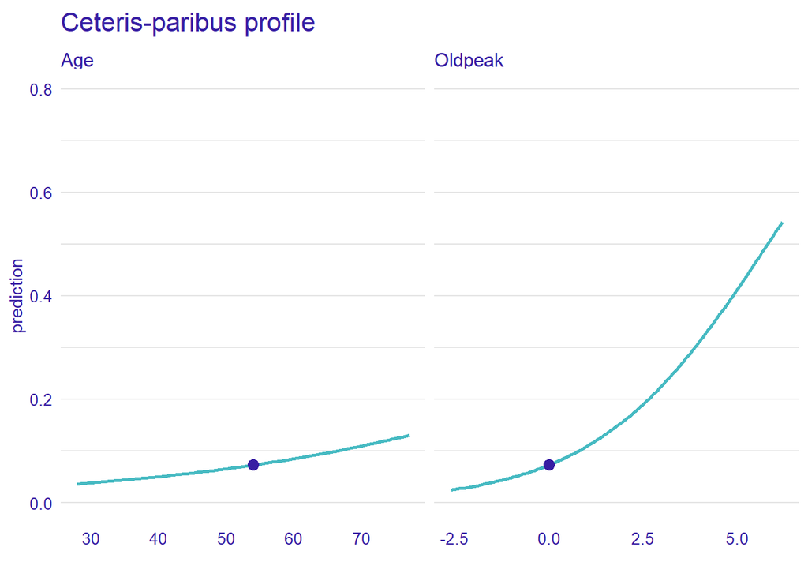

```r
plot(cp_model1, variables = c("Oldpeak","Age")) +
  ggtitle("Ceteris-paribus profile", "") + ylim(0, 0.8)
```

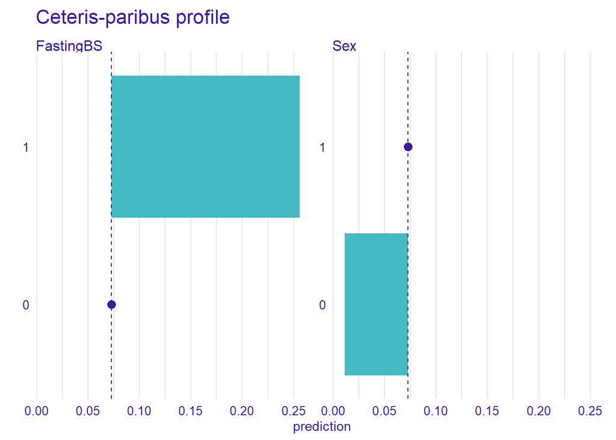

```r
plot(cp_model1, variables = c("Sex", "FastingBS"),
     variable_type = "categorical", categorical_type = "bars") +
  ggtitle("Ceteris-paribus profile", "")
```

Obrazek przedstawia wykresy ceteris paribus dla dwóch zmiennych: “FastingBS” i “Sex”, w kontekście zmiennej wynikowej, która jest chorobą serca. Zmienna wynikowa przyjmuje wartości 0 lub 1, gdzie 1 oznacza występowanie choroby serca.

Na pierwszym wykresie, dla zmiennej “FastingBS” , widać, że kiedy wartość tej zmiennej wynosi 1, prawdopodobieństwo wystąpienia choroby serca jest znacznie wyższe niż kiedy wartość wynosi 0. Sugeruje to silny związek między wysokim poziomem glukozy na czczo a chorobą serca.

Na drugim wykresie, dla zmiennej “Sex”, Wykres pokazuje, że prawdopodobieństwo wystąpienia choroby serca jest wyższe dla kategorii “1” niż dla “0”, co może wskazywać na to, że mężczyźni są bardziej narażeni na chorobę serca niż kobiety w tej szczególnej analizie.

## Wykresy częściowej zależności (PDP)

Zmienne ilościowe:

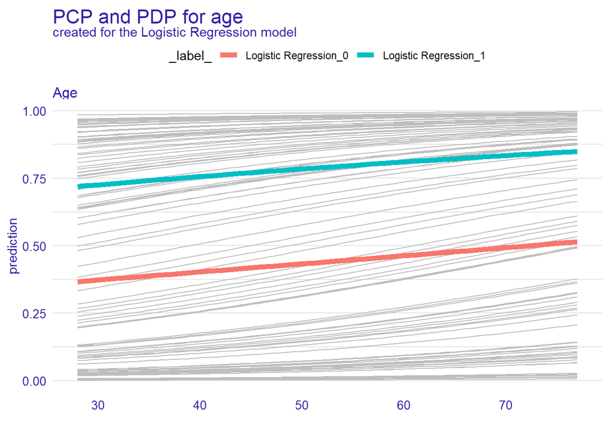

```r
pdp <- model_profile(explainer = explain_model1, variables = "Age", groups="FastingBS")
plot(pdp, geom = "profiles") +
  ggtitle("PCP and PDP for age")
```

Wykres przedstawia PCP i PDP dla zmiennej age.Na wykresie możemy zobserwować szare linie oznaczające funkcje PCP dla 100 losowo wybranych obserwacji. Na niebieseko i na czerwono możemy zobserwować PDP dla zmiennej age w zależności od wartości zmiennej FastingBS (na czerwono “0”, na niebiesko “1”). Na podstawie informacji zawartych na wykresie możemy wysunąć wnioski, że zmienna Age, przy wartości FastingBS równej 0 charakteryzuje się mniejszym prawdopodobieństem wystąpienia klasy pozytywnej niż w przypadku wartości równej 1. W obu przypadkach wraz z wzrostem wartości zmiennej Age rośnie prawdopodobieństwo wystąpienia predykcji klasy pozytywnej.

Zmienne kategoryczne:

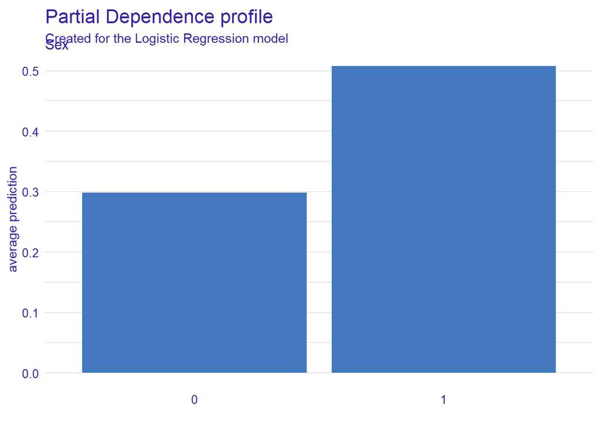

```r
pdp <- model_profile(explainer = explain_model1, variables = "Sex", variable_type = "categorical")
plot(pdp)
```

Wykres słupkowy przedstawia Partial Dependence Profile dla zmiennej zależnej “płeć” w kontekście zmiennej wynikowej, która jest chorobą serca, w modelu regresji logistycznej. Interpretacja tego wykresu sugeruje, że w analizowanym modelu regresji logistycznej, płeć ma wpływ na przewidywane prawdopodobieństwo wystąpienia choroby serca – mężczyźni mają wyższe przewidywane prawdopodobieństwo niż kobiety .

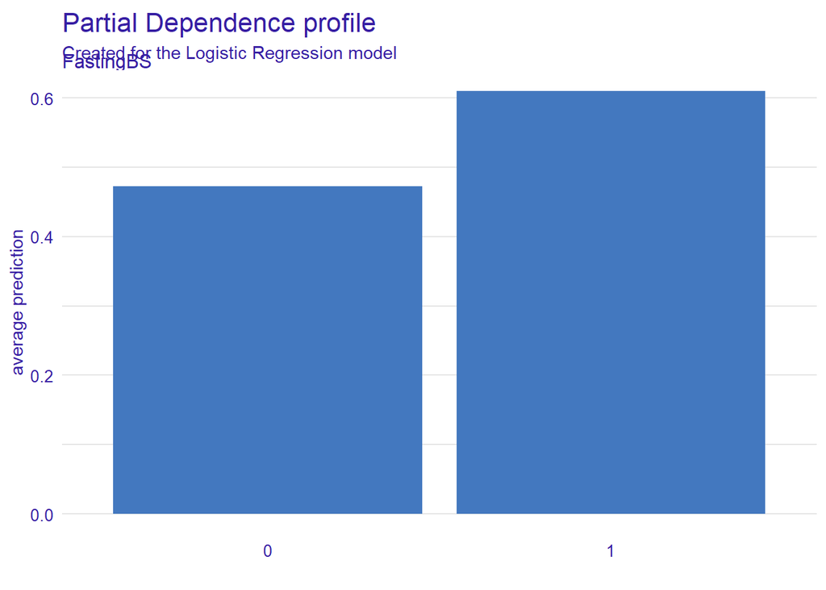

```r
pdp <- model_profile(explainer = explain_model1, variables = "FastingBS", variable_type = "categorical")
plot(pdp)
```

Na tym wykresie widzimy, że dla obu wartosci fastingbs prawdopodobieństwo wystąpienia klasy pozytywnej jest wyższe niz w przypadku zmiennej opisujacej płec. Możemy rownież zauważyż, że dla wartożci 1 prawdopodobińestwo jest wyższe niż w przyapdku wartości 0.

## Wartości SHAP

Wykresy BD (Break-down Plots for Interactions)

```r
obs=train_set[100,]
obs
```

```
##     Age Sex RestingBP Cholesterol FastingBS MaxHR ExerciseAngina Oldpeak
## 142  59   1       130         290         0   100              0       2
##     ChestPainTypeASY ChestPainTypeATA ChestPainTypeNAP RestingECGLVH
## 142                1                0                0             0
##     RestingECGNormal STSlopeDown STSlopeFlat heartDisease
## 142                1           0           1            1
```

```r
predict(model1, obs, type="response")
```

```
##       142
## 0.9536023
```

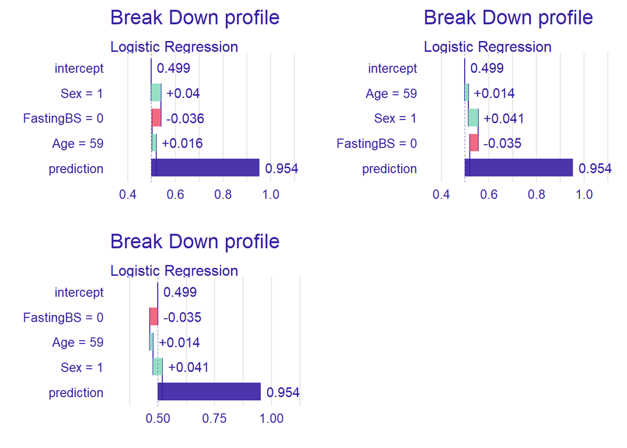

```r
bd1 <- predict_parts(explainer = explain_model1,
                     new_observation = obs,
                     type = "break_down_interactions",
                     order = c("Sex", "FastingBS", "Age"))
p1 <- plot(bd1)
bd2 <- predict_parts(explainer = explain_model1,
                     new_observation = obs,
                     type = "break_down_interactions",
                     order =  c("Age", "Sex", "FastingBS"))
p2 <- plot(bd2)
bd3 <- predict_parts(explainer = explain_model1,
                     new_observation = obs,
                     type = "break_down_interactions",
                     order =  c( "FastingBS", "Age","Sex"))
p3 <- plot(bd3)
library(gridExtra)
grid.arrange(p1, p2, p3, nrow = 2)
```

Na wykresach Break Down każda zmienna ma przypisaną wartość, która reprezentuje jej wkład do przewidywania modelu. Wartości mogą być dodatnie (zwiększające prawdopodobieństwo wystąpienia zdarzenia) lub ujemne (zmniejszające prawdopodobieństwo). Na przykład, jeśli ‘Sex = 1’ ma dodatni wkład, oznacza to, że bycie w tej kategorii płci zwiększa prawdopodobieństwo przewidywanego zdarzenia w porównaniu do ‘Sex = 0’. Możemy zaobserwować, że w przypadku zmiennej FastingBS równej 0 w naszej obserwacji zmniejsza prawdopodobieństwo, przeciwnie w przypadku gdyby była równa 1.

**Wartości SHAP**

Uśrednienie wartości (udziałów) przypisanych danej zmiennej z wszystkich możliwych uporządkowań.

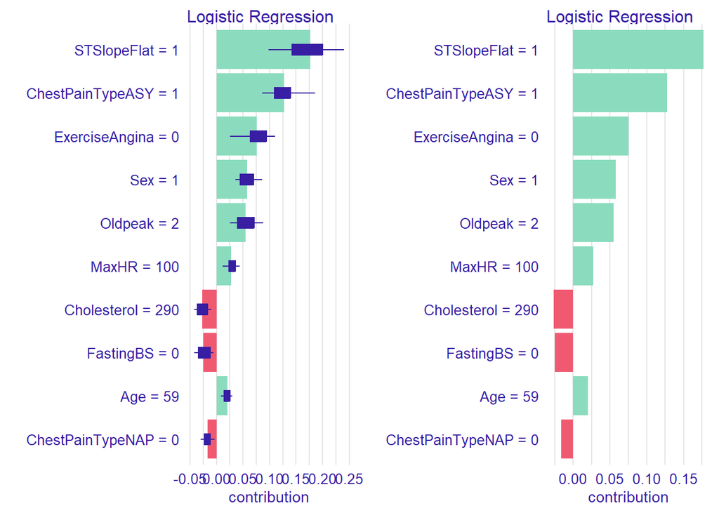

```r
shap <- predict_parts(explainer = explain_model1,
                      new_observation = obs,
                      type = "shap")
p1 <- plot(shap)
p2 <- plot(shap, show_boxplots = FALSE)
grid.arrange(p1, p2, nrow = 1)
```

Wykresy SHAP prezentują wkład poszczególnych zmiennych do przewidywania modelu. Wartości na wykresach reprezentują wpływ, jaki każda zmienna miała na decyzję modelu; wartości dodatnie zwiększają prawdopodobieństwo wyniku modelu, a wartości ujemne je zmniejszają. Wykresy te pozwalają zrozumieć, które zmienne są najważniejsze dla przewidywań modelu i jak konkretnie wpływają na te przewidywania. Interpretując wykres wkładu zmiennych dla naszej wybranej obserwacji możęmy dojść do wniosku, że największy wpływ w danym przypadku otrzymaliśmy dla zmiennych STSlopeFlat przyjmującego wartość 1. Ciekawą obserwacją również jest fakt, że w naszym przypadku największy wpływ mają zmienne kategoryczne.